# 19BCE1717 Lab 8

Makesh Srinivasan

3/19/2022

Registration number: 19BCE1717  
Faculty: Prof. Radha R  
Slot: L37 + L38  
Course code: CSE3505

## Gradient Descent - Optimization

## Sections:

- Question 1
- Question 2

**Question 1:** Minimize the function

**f(x) = 1.2 * (x-2)^2 + 3.2**

##### Create a sequence of elements in a Vector to generate sequences when plotting the axes of figures or simulating data.

```r
xs <- seq(0,4,len=20)
xs
```

```
##  [1] 0.0000000 0.2105263 0.4210526 0.6315789 0.8421053 1.0526316 1.2631579
##  [8] 1.4736842 1.6842105 1.8947368 2.1052632 2.3157895 2.5263158 2.7368421
## [15] 2.9473684 3.1578947 3.3684211 3.5789474 3.7894737 4.0000000
```

##### Define the function we want to optimize

```r
f <- function(x) {
  1.2 * (x-2)^2 + 3.2
}
```

##### Plot the function

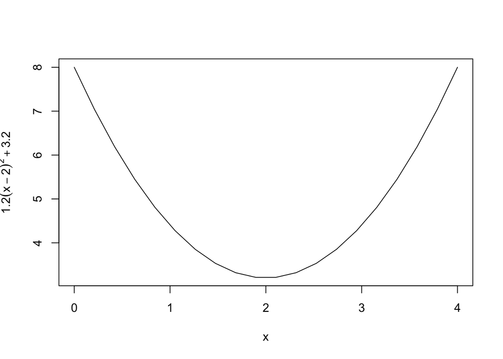

```r
# plot the function
plot(xs , f (xs), type="l",xlab="x",ylab=expression(1.2(x-2)^2 +3.2))
```

##### Create a function for gradient df/dx

f’(x) = df/dx = 2.4(x-2)

```r
grad <- function(x){
  1.2*2*(x-2)
}
```

df/dx = 2.4(x-2), if x = 2 then 2.4(2-2) = 0  
The actual solution we will approximate with gradient descent is x = 2 as depicted in the plot below

##### Gradient descent implementation

```r
x <- 0.1 # initialize the first guess for x-value
xtrace <- x  # store x -values for graphing purposes (initial)
ftrace <- f(x) # store y-values (function evaluated at x) for graphing purposes (initial)
stepFactor <- 0.01 # learning rate 'alpha'
for (step in 1:5000) {
  x <- x - stepFactor*grad(x) # gradient descent update
  xtrace <- c(xtrace,x) # update for graph
  ftrace <- c(ftrace,f(x)) # update for graph
}
```

##### Plot the gradient descent with the global minimum (optimised)

```r
plot(xs, f(xs), type="l", xlab="x", ylab=expression(1.2(x-2)^2 +3.2))
lines(xtrace, ftrace, type="b", col="blue") # type=b (both points & lines)
text(0.5,6, "Gradient Descent",col="red",pos= 4)
print(x) # x converges to 2.0
```

```
## [1] 2
```

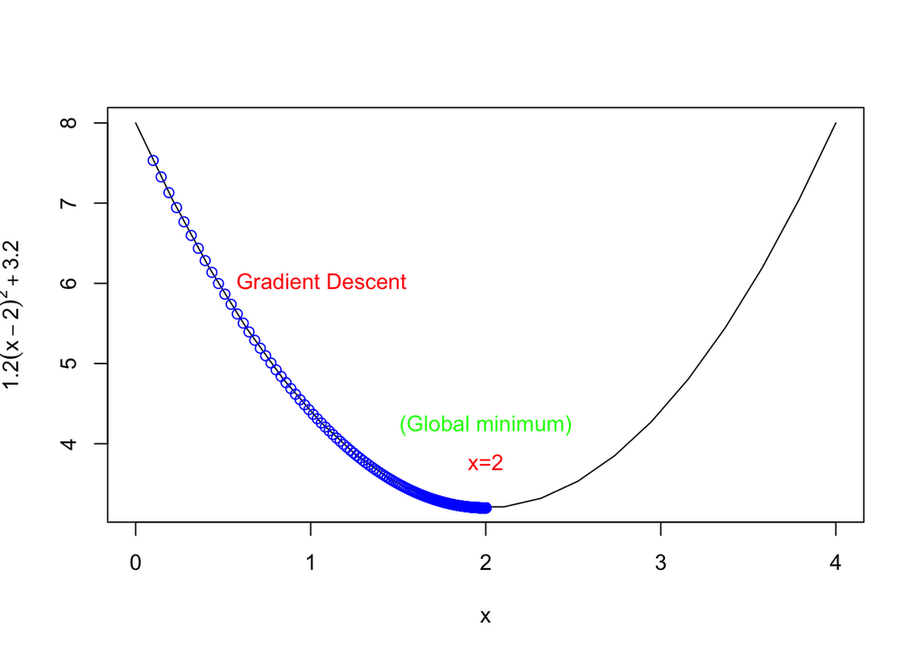

```r
# now place the texts global minimum and x = 2
text(2, 4, "x=2",col="red",pos=1)
text(2, 4, "(Global minimum)",col="green", pos=3)
```

**Question 2:** Minimize the function

**f(x) = 3x^2 + 2x + 1**

Basic calculus requires that we find the 1st derivative, and solve for the value of x such that f’(x) = 0.  
1) f’(x) = 6x + 2  
2) step factor/learning rate = 0.01  
3) initial x value = 0.1  
Find the values of x that minimize the function above, and plots the progress of the algorithm with each iteration.

##### Create a sequence of elements in a Vector to generate sequences when plotting the axes of figures or simulating data.

```r
xs <- seq(-2,2,len=20)
xs
```

```
##  [1] -2.0000000 -1.7894737 -1.5789474 -1.3684211 -1.1578947 -0.9473684
##  [7] -0.7368421 -0.5263158 -0.3157895 -0.1052632  0.1052632  0.3157895
## [13]  0.5263158  0.7368421  0.9473684  1.1578947  1.3684211  1.5789474
## [19]  1.7894737  2.0000000
```

##### Define the function we want to optimize

```r
f <- function(x) {
  3*x*x + 2*x + 1
}
```

##### Plot the function

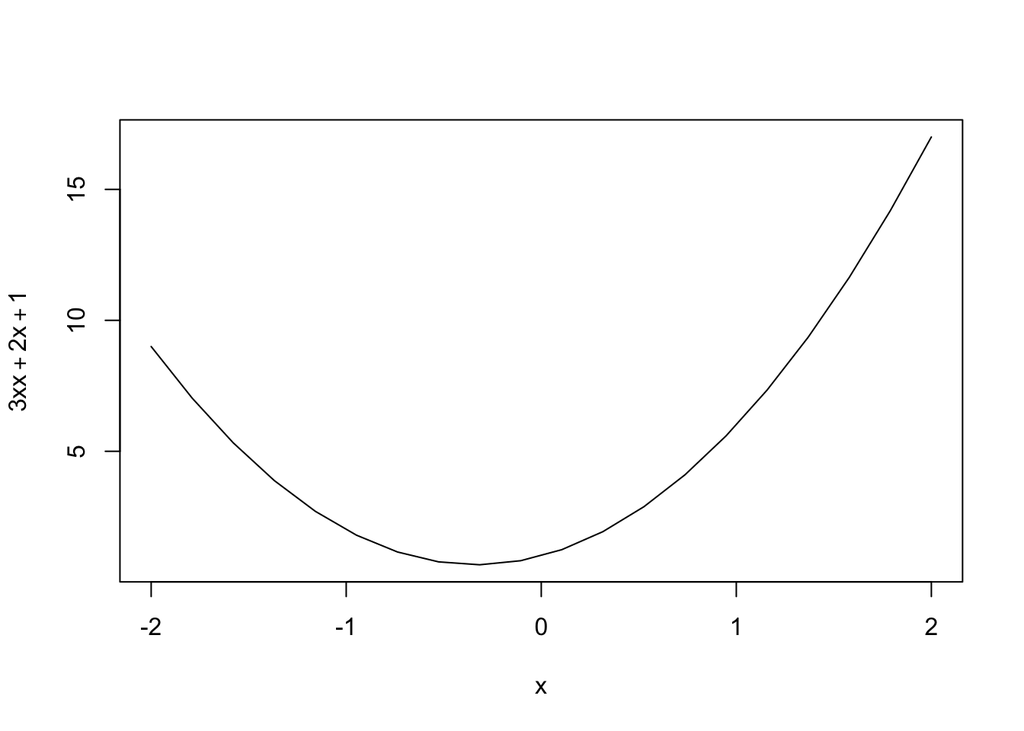

```r
# plot the function
plot(xs , f (xs), type="l",xlab="x",ylab=expression(3*x*x + 2*x + 1))
```

##### Create a function for gradient df/dx

f’(x) = df/dx = 6x + 2

```r
grad <- function(x){
  6*x + 2
}
```

df/dx = 6x + 2, if x = -1/3 then 6x + 2 = 0  
The actual solution we will approximate with gradient descent is x = -1/3 as depicted in the plot below

##### Gradient descent implementation

```r
x <- 0.1 # initialize the first guess for x-value
xtrace <- x  # store x -values for graphing purposes (initial)
ftrace <- f(x) # store y-values (function evaluated at x) for graphing purposes (initial)
stepFactor <- 0.01 # learning rate 'alpha'
for (step in 1:5000) {
  x <- x - stepFactor*grad(x) # gradient descent update
  xtrace <- c(xtrace,x) # update for graph
  ftrace <- c(ftrace,f(x)) # update for graph
}
```

##### Plot the gradient descent with the global minimum (optimised)

```r
plot(xs, f(xs), type="l", xlab="x", ylab=expression(3*x^2 + 2*x + 1))
lines(xtrace, ftrace, type="b", col="blue") # type=b (both points & lines)
text(-2,10, "Gradient Descent",col="red",pos= 4)
print(x) # x converges to -1/3
```

```
## [1] -0.3333333
```

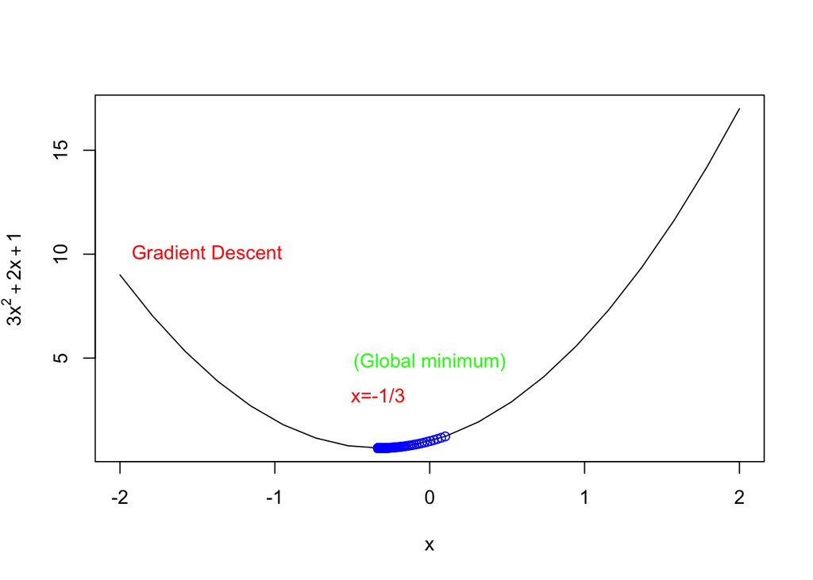

```r
# now place the texts global minimum and x = -1/3
text(-1/3, 4, "x=-1/3",col="red",pos=1)
text(0, 4, "(Global minimum)",col="green", pos=3)
```